# Risk Factor Analysis

## Outcome Variable

**Outcome Variable:** stunted

## Predictor Variables

**Intervention Variable:** birthlen

**Adjustment Set:**

- arm
- sex
- W_mage
- meducyrs
- feducyrs
- vagbrth
- single
- brthmon
- W_parity
- delta_W_mage
- delta_meducyrs
- delta_feducyrs
- delta_vagbrth
- delta_single
- delta_brthmon
- delta_W_parity

## Stratifying Variables

The analysis was stratified on these variable(s):

- agecat
- studyid
- country

## Data Summary

| agecat | studyid | country | birthlen | stunted | n_cell | n |
| --- | --- | --- | --- | --- | --- | --- |
| Birth | CMC-V-BCS-2002 | INDIA | >=50 cm | 0 | 14 | 92 |
| Birth | CMC-V-BCS-2002 | INDIA | >=50 cm | 1 | 0 | 92 |
| Birth | CMC-V-BCS-2002 | INDIA | <48 cm | 0 | 21 | 92 |
| Birth | CMC-V-BCS-2002 | INDIA | <48 cm | 1 | 17 | 92 |
| Birth | CMC-V-BCS-2002 | INDIA | [48-50) cm | 0 | 40 | 92 |
| Birth | CMC-V-BCS-2002 | INDIA | [48-50) cm | 1 | 0 | 92 |
| Birth | CMIN | BANGLADESH | >=50 cm | 0 | 2 | 26 |
| Birth | CMIN | BANGLADESH | >=50 cm | 1 | 0 | 26 |
| Birth | CMIN | BANGLADESH | <48 cm | 0 | 7 | 26 |
| Birth | CMIN | BANGLADESH | <48 cm | 1 | 9 | 26 |
| Birth | CMIN | BANGLADESH | [48-50) cm | 0 | 8 | 26 |
| Birth | CMIN | BANGLADESH | [48-50) cm | 1 | 0 | 26 |
| Birth | COHORTS | GUATEMALA | >=50 cm | 0 | 437 | 852 |
| Birth | COHORTS | GUATEMALA | >=50 cm | 1 | 0 | 852 |
| Birth | COHORTS | GUATEMALA | <48 cm | 0 | 113 | 852 |
| Birth | COHORTS | GUATEMALA | <48 cm | 1 | 50 | 852 |
| Birth | COHORTS | GUATEMALA | [48-50) cm | 0 | 252 | 852 |
| Birth | COHORTS | GUATEMALA | [48-50) cm | 1 | 0 | 852 |
| Birth | COHORTS | INDIA | >=50 cm | 0 | 1426 | 6640 |
| Birth | COHORTS | INDIA | >=50 cm | 1 | 0 | 6640 |
| Birth | COHORTS | INDIA | <48 cm | 0 | 1982 | 6640 |
| Birth | COHORTS | INDIA | <48 cm | 1 | 792 | 6640 |
| Birth | COHORTS | INDIA | [48-50) cm | 0 | 2440 | 6640 |
| Birth | COHORTS | INDIA | [48-50) cm | 1 | 0 | 6640 |
| Birth | COHORTS | PHILIPPINES | >=50 cm | 0 | 1129 | 3050 |
| Birth | COHORTS | PHILIPPINES | >=50 cm | 1 | 0 | 3050 |
| Birth | COHORTS | PHILIPPINES | <48 cm | 0 | 575 | 3050 |
| Birth | COHORTS | PHILIPPINES | <48 cm | 1 | 187 | 3050 |
| Birth | COHORTS | PHILIPPINES | [48-50) cm | 0 | 1159 | 3050 |
| Birth | COHORTS | PHILIPPINES | [48-50) cm | 1 | 0 | 3050 |

[output cut: 426 more lines]

The following strata were considered:

- agecat: 24 months, studyid: CMC-V-BCS-2002, country: INDIA
- agecat: 24 months, studyid: CMIN, country: BANGLADESH
- agecat: 24 months, studyid: COHORTS, country: GUATEMALA
- agecat: 24 months, studyid: COHORTS, country: INDIA
- agecat: 24 months, studyid: COHORTS, country: PHILIPPINES
- agecat: 24 months, studyid: CONTENT, country: PERU
- agecat: 24 months, studyid: EE, country: PAKISTAN
- agecat: 24 months, studyid: GMS-Nepal, country: NEPAL
- agecat: 24 months, studyid: IRC, country: INDIA
- agecat: 24 months, studyid: JiVitA-3, country: BANGLADESH
- agecat: 24 months, studyid: JiVitA-4, country: BANGLADESH
- agecat: 24 months, studyid: Keneba, country: GAMBIA
- agecat: 24 months, studyid: MAL-ED, country: BANGLADESH
- agecat: 24 months, studyid: MAL-ED, country: BRAZIL
- agecat: 24 months, studyid: MAL-ED, country: INDIA
- agecat: 24 months, studyid: MAL-ED, country: NEPAL
- agecat: 24 months, studyid: MAL-ED, country: PERU
- agecat: 24 months, studyid: MAL-ED, country: SOUTH AFRICA
- agecat: 24 months, studyid: MAL-ED, country: TANZANIA, UNITED REPUBLIC OF
- agecat: 24 months, studyid: NIH-Birth, country: BANGLADESH
- agecat: 24 months, studyid: NIH-Crypto, country: BANGLADESH
- agecat: 24 months, studyid: PROBIT, country: BELARUS
- agecat: 24 months, studyid: PROVIDE, country: BANGLADESH
- agecat: 24 months, studyid: ZVITAMBO, country: ZIMBABWE
- agecat: 6 months, studyid: CMC-V-BCS-2002, country: INDIA
- agecat: 6 months, studyid: CMIN, country: BANGLADESH
- agecat: 6 months, studyid: COHORTS, country: GUATEMALA
- agecat: 6 months, studyid: COHORTS, country: INDIA
- agecat: 6 months, studyid: COHORTS, country: PHILIPPINES
- agecat: 6 months, studyid: CONTENT, country: PERU
- agecat: 6 months, studyid: EE, country: PAKISTAN
- agecat: 6 months, studyid: GMS-Nepal, country: NEPAL
- agecat: 6 months, studyid: IRC, country: INDIA
- agecat: 6 months, studyid: JiVitA-3, country: BANGLADESH
- agecat: 6 months, studyid: JiVitA-4, country: BANGLADESH
- agecat: 6 months, studyid: Keneba, country: GAMBIA
- agecat: 6 months, studyid: MAL-ED, country: BANGLADESH
- agecat: 6 months, studyid: MAL-ED, country: BRAZIL
- agecat: 6 months, studyid: MAL-ED, country: INDIA
- agecat: 6 months, studyid: MAL-ED, country: NEPAL
- agecat: 6 months, studyid: MAL-ED, country: PERU
- agecat: 6 months, studyid: MAL-ED, country: SOUTH AFRICA
- agecat: 6 months, studyid: MAL-ED, country: TANZANIA, UNITED REPUBLIC OF
- agecat: 6 months, studyid: NIH-Birth, country: BANGLADESH
- agecat: 6 months, studyid: NIH-Crypto, country: BANGLADESH
- agecat: 6 months, studyid: PROBIT, country: BELARUS
- agecat: 6 months, studyid: PROVIDE, country: BANGLADESH
- agecat: 6 months, studyid: ResPak, country: PAKISTAN
- agecat: 6 months, studyid: SAS-CompFeed, country: INDIA
- agecat: 6 months, studyid: ZVITAMBO, country: ZIMBABWE
- agecat: Birth, studyid: CMC-V-BCS-2002, country: INDIA
- agecat: Birth, studyid: CMIN, country: BANGLADESH
- agecat: Birth, studyid: COHORTS, country: GUATEMALA
- agecat: Birth, studyid: COHORTS, country: INDIA
- agecat: Birth, studyid: COHORTS, country: PHILIPPINES
- agecat: Birth, studyid: CONTENT, country: PERU
- agecat: Birth, studyid: EE, country: PAKISTAN
- agecat: Birth, studyid: GMS-Nepal, country: NEPAL
- agecat: Birth, studyid: IRC, country: INDIA
- agecat: Birth, studyid: JiVitA-3, country: BANGLADESH
- agecat: Birth, studyid: JiVitA-4, country: BANGLADESH
- agecat: Birth, studyid: Keneba, country: GAMBIA
- agecat: Birth, studyid: MAL-ED, country: BANGLADESH
- agecat: Birth, studyid: MAL-ED, country: BRAZIL
- agecat: Birth, studyid: MAL-ED, country: INDIA
- agecat: Birth, studyid: MAL-ED, country: NEPAL
- agecat: Birth, studyid: MAL-ED, country: PERU
- agecat: Birth, studyid: MAL-ED, country: SOUTH AFRICA
- agecat: Birth, studyid: MAL-ED, country: TANZANIA, UNITED REPUBLIC OF
- agecat: Birth, studyid: NIH-Birth, country: BANGLADESH
- agecat: Birth, studyid: NIH-Crypto, country: BANGLADESH
- agecat: Birth, studyid: PROBIT, country: BELARUS
- agecat: Birth, studyid: PROVIDE, country: BANGLADESH
- agecat: Birth, studyid: ResPak, country: PAKISTAN
- agecat: Birth, studyid: SAS-CompFeed, country: INDIA
- agecat: Birth, studyid: ZVITAMBO, country: ZIMBABWE

### Dropped Strata

Some strata were dropped due to rare outcomes:

- agecat: Birth, studyid: CMC-V-BCS-2002, country: INDIA
- agecat: Birth, studyid: CMIN, country: BANGLADESH
- agecat: Birth, studyid: COHORTS, country: GUATEMALA
- agecat: Birth, studyid: COHORTS, country: INDIA
- agecat: Birth, studyid: COHORTS, country: PHILIPPINES
- agecat: Birth, studyid: CONTENT, country: PERU
- agecat: Birth, studyid: EE, country: PAKISTAN
- agecat: Birth, studyid: GMS-Nepal, country: NEPAL
- agecat: Birth, studyid: IRC, country: INDIA
- agecat: Birth, studyid: JiVitA-3, country: BANGLADESH
- agecat: Birth, studyid: JiVitA-4, country: BANGLADESH
- agecat: Birth, studyid: Keneba, country: GAMBIA
- agecat: Birth, studyid: MAL-ED, country: BANGLADESH
- agecat: Birth, studyid: MAL-ED, country: BRAZIL
- agecat: Birth, studyid: MAL-ED, country: INDIA
- agecat: Birth, studyid: MAL-ED, country: NEPAL
- agecat: Birth, studyid: MAL-ED, country: PERU
- agecat: Birth, studyid: MAL-ED, country: SOUTH AFRICA
- agecat: Birth, studyid: MAL-ED, country: TANZANIA, UNITED REPUBLIC OF
- agecat: Birth, studyid: NIH-Birth, country: BANGLADESH
- agecat: Birth, studyid: NIH-Crypto, country: BANGLADESH
- agecat: Birth, studyid: PROBIT, country: BELARUS
- agecat: Birth, studyid: PROVIDE, country: BANGLADESH
- agecat: Birth, studyid: ResPak, country: PAKISTAN
- agecat: Birth, studyid: SAS-CompFeed, country: INDIA
- agecat: Birth, studyid: ZVITAMBO, country: ZIMBABWE
- agecat: 6 months, studyid: CMIN, country: BANGLADESH
- agecat: 6 months, studyid: CONTENT, country: PERU
- agecat: 6 months, studyid: EE, country: PAKISTAN
- agecat: 6 months, studyid: GMS-Nepal, country: NEPAL
- agecat: 6 months, studyid: MAL-ED, country: BANGLADESH
- agecat: 6 months, studyid: MAL-ED, country: BRAZIL
- agecat: 6 months, studyid: MAL-ED, country: INDIA
- agecat: 6 months, studyid: MAL-ED, country: NEPAL
- agecat: 6 months, studyid: MAL-ED, country: PERU
- agecat: 6 months, studyid: MAL-ED, country: SOUTH AFRICA
- agecat: 6 months, studyid: MAL-ED, country: TANZANIA, UNITED REPUBLIC OF
- agecat: 6 months, studyid: NIH-Crypto, country: BANGLADESH
- agecat: 6 months, studyid: PROVIDE, country: BANGLADESH
- agecat: 6 months, studyid: ResPak, country: PAKISTAN
- agecat: 24 months, studyid: CMIN, country: BANGLADESH
- agecat: 24 months, studyid: CONTENT, country: PERU
- agecat: 24 months, studyid: EE, country: PAKISTAN
- agecat: 24 months, studyid: MAL-ED, country: BRAZIL
- agecat: 24 months, studyid: MAL-ED, country: INDIA
- agecat: 24 months, studyid: MAL-ED, country: NEPAL

## Methods Detail

We’re interested in the causal parameters $E[Y_a]$ for all values of $a \in \mathcal{A}$. These parameters represent the mean outcome if, possibly contrary to fact, we intervened to set all units to have $A=a$. Under the randomization and positivity assumptions, these are identified by the statistical parameters $\psi_a=E_W[E_{Y|A,W}(Y|A=a,W)]$. In addition, we’re interested in the mean of $Y$, $E[Y]$ under no intervention (the observed mean). We will estimate these parameters by using SuperLearner to fit the relevant likelihood factors – $E_{Y|A,W}(Y|A=a,W)$ and $p(A=a|W)$, and then updating our likelihood fit using a joint TMLE.

For unadjusted analyses ($W=\{\}$), initial likelihoods were estimated using Lrnr_glm to estimate the simple $E(Y|A)$ and Lrnr_mean to estimate $p(A)$. For adjusted analyses, a small library containing Lrnr_glmnet, Lrnr_xgboost, and Lrnr_mean was used.

Having estimated these parameters, we will then use the delta method to estimate relative risks and attributable risks relative to a prespecified baseline level of $A$.

# Results Detail

## Results Plots

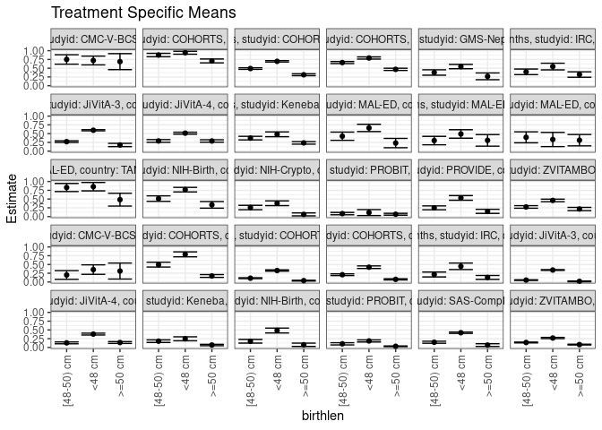

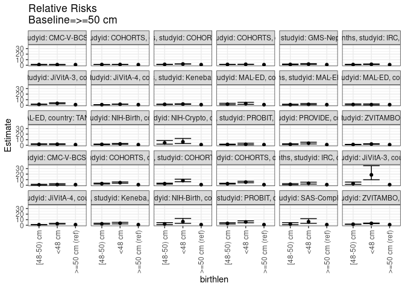

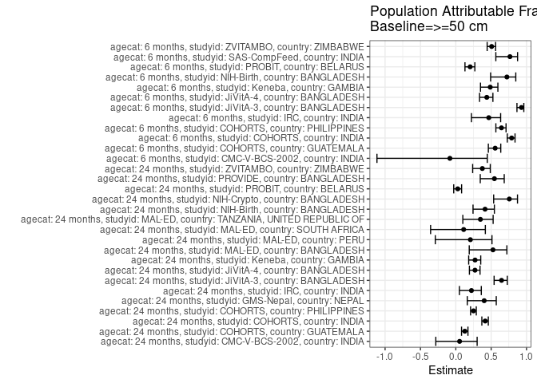

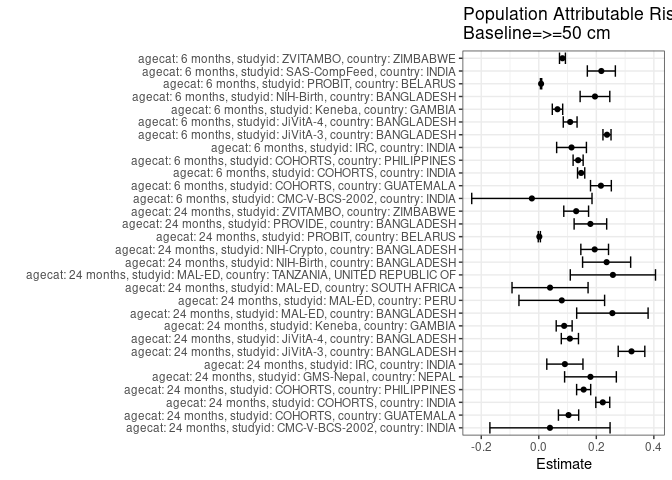

## Results Table

### Parameter: TSM

| agecat | studyid | country | intervention_level | baseline_level | estimate | ci_lower | ci_upper |
| --- | --- | --- | --- | --- | --- | --- | --- |
| 6 months | CMC-V-BCS-2002 | INDIA | >=50 cm | NA | 0.3125000 | 0.0842832 | 0.5407168 |
| 6 months | CMC-V-BCS-2002 | INDIA | <48 cm | NA | 0.3541667 | 0.2182134 | 0.4901199 |
| 6 months | CMC-V-BCS-2002 | INDIA | [48-50) cm | NA | 0.2000000 | 0.0754407 | 0.3245593 |
| 6 months | COHORTS | GUATEMALA | >=50 cm | NA | 0.1720775 | 0.1320449 | 0.2121100 |
| 6 months | COHORTS | GUATEMALA | <48 cm | NA | 0.7885391 | 0.7179615 | 0.8591167 |
| 6 months | COHORTS | GUATEMALA | [48-50) cm | NA | 0.4953933 | 0.4265028 | 0.5642839 |
| 6 months | COHORTS | INDIA | >=50 cm | NA | 0.0392188 | 0.0288224 | 0.0496151 |
| 6 months | COHORTS | INDIA | <48 cm | NA | 0.3273019 | 0.3089905 | 0.3456133 |
| 6 months | COHORTS | INDIA | [48-50) cm | NA | 0.1082660 | 0.0954948 | 0.1210372 |
| 6 months | COHORTS | PHILIPPINES | >=50 cm | NA | 0.0750211 | 0.0585484 | 0.0914938 |
| 6 months | COHORTS | PHILIPPINES | <48 cm | NA | 0.4225258 | 0.3859984 | 0.4590532 |
| 6 months | COHORTS | PHILIPPINES | [48-50) cm | NA | 0.2074508 | 0.1829201 | 0.2319814 |
| 6 months | IRC | INDIA | >=50 cm | NA | 0.1303681 | 0.0745690 | 0.1861672 |
| 6 months | IRC | INDIA | <48 cm | NA | 0.4478114 | 0.3544523 | 0.5411705 |
| 6 months | IRC | INDIA | [48-50) cm | NA | 0.2142493 | 0.1443445 | 0.2841540 |
| 6 months | JiVitA-3 | BANGLADESH | >=50 cm | NA | 0.0183460 | 0.0067067 | 0.0299853 |
| 6 months | JiVitA-3 | BANGLADESH | <48 cm | NA | 0.3418979 | 0.3309170 | 0.3528789 |
| 6 months | JiVitA-3 | BANGLADESH | [48-50) cm | NA | 0.0541969 | 0.0456255 | 0.0627682 |
| 6 months | JiVitA-4 | BANGLADESH | >=50 cm | NA | 0.1399087 | 0.1142218 | 0.1655956 |
| 6 months | JiVitA-4 | BANGLADESH | <48 cm | NA | 0.3803373 | 0.3538339 | 0.4068406 |
| 6 months | JiVitA-4 | BANGLADESH | [48-50) cm | NA | 0.1302185 | 0.1039297 | 0.1565073 |
| 6 months | Keneba | GAMBIA | >=50 cm | NA | 0.0685959 | 0.0493507 | 0.0878411 |
| 6 months | Keneba | GAMBIA | <48 cm | NA | 0.2463922 | 0.1898406 | 0.3029438 |
| 6 months | Keneba | GAMBIA | [48-50) cm | NA | 0.1783506 | 0.1417628 | 0.2149384 |
| 6 months | NIH-Birth | BANGLADESH | >=50 cm | NA | 0.0750000 | 0.0278286 | 0.1221714 |
| 6 months | NIH-Birth | BANGLADESH | <48 cm | NA | 0.4824121 | 0.4129189 | 0.5519053 |
| 6 months | NIH-Birth | BANGLADESH | [48-50) cm | NA | 0.1758794 | 0.1229321 | 0.2288267 |
| 6 months | PROBIT | BELARUS | >=50 cm | NA | 0.0313655 | 0.0214735 | 0.0412576 |
| 6 months | PROBIT | BELARUS | <48 cm | NA | 0.1850505 | 0.1558530 | 0.2142480 |
| 6 months | PROBIT | BELARUS | [48-50) cm | NA | 0.1028291 | 0.0717723 | 0.1338858 |

[output cut: 60 more lines]

### Parameter: E(Y)

| agecat | studyid | country | intervention_level | baseline_level | estimate | ci_lower | ci_upper |
| --- | --- | --- | --- | --- | --- | --- | --- |
| 6 months | CMC-V-BCS-2002 | INDIA | NA | NA | 0.2884615 | 0.2009687 | 0.3759544 |
| 6 months | COHORTS | GUATEMALA | NA | NA | 0.3880814 | 0.3516414 | 0.4245214 |
| 6 months | COHORTS | INDIA | NA | NA | 0.1864711 | 0.1767241 | 0.1962180 |
| 6 months | COHORTS | PHILIPPINES | NA | NA | 0.2117734 | 0.1963625 | 0.2271843 |
| 6 months | IRC | INDIA | NA | NA | 0.2442159 | 0.2014677 | 0.2869642 |
| 6 months | JiVitA-3 | BANGLADESH | NA | NA | 0.2554582 | 0.2465868 | 0.2643296 |
| 6 months | JiVitA-4 | BANGLADESH | NA | NA | 0.2490050 | 0.2328619 | 0.2651480 |
| 6 months | Keneba | GAMBIA | NA | NA | 0.1336303 | 0.1154530 | 0.1518076 |
| 6 months | NIH-Birth | BANGLADESH | NA | NA | 0.2702703 | 0.2319893 | 0.3085512 |
| 6 months | PROBIT | BELARUS | NA | NA | 0.0393401 | 0.0293640 | 0.0493162 |
| 6 months | SAS-CompFeed | INDIA | NA | NA | 0.2839879 | 0.2652870 | 0.3026888 |
| 6 months | ZVITAMBO | ZIMBABWE | NA | NA | 0.1624111 | 0.1546051 | 0.1702171 |
| 24 months | CMC-V-BCS-2002 | INDIA | NA | NA | 0.7264151 | 0.6411459 | 0.8116842 |
| 24 months | COHORTS | GUATEMALA | NA | NA | 0.8107143 | 0.7782403 | 0.8431882 |
| 24 months | COHORTS | INDIA | NA | NA | 0.5350988 | 0.5209252 | 0.5492723 |
| 24 months | COHORTS | PHILIPPINES | NA | NA | 0.6232596 | 0.6040367 | 0.6424826 |
| 24 months | GMS-Nepal | NEPAL | NA | NA | 0.4476386 | 0.4034301 | 0.4918471 |
| 24 months | IRC | INDIA | NA | NA | 0.4102564 | 0.3613763 | 0.4591366 |
| 24 months | JiVitA-3 | BANGLADESH | NA | NA | 0.4981904 | 0.4842373 | 0.5121435 |
| 24 months | JiVitA-4 | BANGLADESH | NA | NA | 0.3982945 | 0.3795521 | 0.4170368 |
| 24 months | Keneba | GAMBIA | NA | NA | 0.3239437 | 0.2958244 | 0.3520629 |
| 24 months | MAL-ED | BANGLADESH | NA | NA | 0.4866310 | 0.4148009 | 0.5584611 |
| 24 months | MAL-ED | PERU | NA | NA | 0.3875000 | 0.3117751 | 0.4632249 |
| 24 months | MAL-ED | SOUTH AFRICA | NA | NA | 0.3516484 | 0.2530008 | 0.4502959 |
| 24 months | MAL-ED | TANZANIA, UNITED REPUBLIC OF | NA | NA | 0.7403846 | 0.6557158 | 0.8250534 |
| 24 months | NIH-Birth | BANGLADESH | NA | NA | 0.5700483 | 0.5223021 | 0.6177945 |
| 24 months | NIH-Crypto | BANGLADESH | NA | NA | 0.2568093 | 0.2190047 | 0.2946140 |
| 24 months | PROBIT | BELARUS | NA | NA | 0.0681537 | 0.0420376 | 0.0942697 |
| 24 months | PROVIDE | BANGLADESH | NA | NA | 0.3287197 | 0.2903909 | 0.3670485 |
| 24 months | ZVITAMBO | ZIMBABWE | NA | NA | 0.3463930 | 0.3231291 | 0.3696570 |

### Parameter: RR

| agecat | studyid | country | intervention_level | baseline_level | estimate | ci_lower | ci_upper |
| --- | --- | --- | --- | --- | --- | --- | --- |
| 6 months | CMC-V-BCS-2002 | INDIA | >=50 cm | >=50 cm | 1.0000000 | 1.0000000 | 1.000000 |
| 6 months | CMC-V-BCS-2002 | INDIA | <48 cm | >=50 cm | 1.1333333 | 0.4966487 | 2.586223 |
| 6 months | CMC-V-BCS-2002 | INDIA | [48-50) cm | >=50 cm | 0.6400000 | 0.2451020 | 1.671141 |
| 6 months | COHORTS | GUATEMALA | >=50 cm | >=50 cm | 1.0000000 | 1.0000000 | 1.000000 |
| 6 months | COHORTS | GUATEMALA | <48 cm | >=50 cm | 4.5824656 | 3.5710076 | 5.880411 |
| 6 months | COHORTS | GUATEMALA | [48-50) cm | >=50 cm | 2.8788971 | 2.1953100 | 3.775343 |
| 6 months | COHORTS | INDIA | >=50 cm | >=50 cm | 1.0000000 | 1.0000000 | 1.000000 |
| 6 months | COHORTS | INDIA | <48 cm | >=50 cm | 8.3455384 | 6.3668944 | 10.939087 |
| 6 months | COHORTS | INDIA | [48-50) cm | >=50 cm | 2.7605652 | 2.0665542 | 3.687646 |
| 6 months | COHORTS | PHILIPPINES | >=50 cm | >=50 cm | 1.0000000 | 1.0000000 | 1.000000 |
| 6 months | COHORTS | PHILIPPINES | <48 cm | >=50 cm | 5.6320904 | 4.4521405 | 7.124762 |
| 6 months | COHORTS | PHILIPPINES | [48-50) cm | >=50 cm | 2.7652309 | 2.1572245 | 3.544602 |
| 6 months | IRC | INDIA | >=50 cm | >=50 cm | 1.0000000 | 1.0000000 | 1.000000 |
| 6 months | IRC | INDIA | <48 cm | >=50 cm | 3.4349764 | 2.1380622 | 5.518578 |
| 6 months | IRC | INDIA | [48-50) cm | >=50 cm | 1.6434177 | 0.9601805 | 2.812827 |
| 6 months | JiVitA-3 | BANGLADESH | >=50 cm | >=50 cm | 1.0000000 | 1.0000000 | 1.000000 |
| 6 months | JiVitA-3 | BANGLADESH | <48 cm | >=50 cm | 18.6360934 | 9.8795541 | 35.153811 |
| 6 months | JiVitA-3 | BANGLADESH | [48-50) cm | >=50 cm | 2.9541503 | 1.5311818 | 5.699522 |
| 6 months | JiVitA-4 | BANGLADESH | >=50 cm | >=50 cm | 1.0000000 | 1.0000000 | 1.000000 |
| 6 months | JiVitA-4 | BANGLADESH | <48 cm | >=50 cm | 2.7184676 | 2.2315804 | 3.311584 |
| 6 months | JiVitA-4 | BANGLADESH | [48-50) cm | >=50 cm | 0.9307392 | 0.7126349 | 1.215595 |
| 6 months | Keneba | GAMBIA | >=50 cm | >=50 cm | 1.0000000 | 1.0000000 | 1.000000 |
| 6 months | Keneba | GAMBIA | <48 cm | >=50 cm | 3.5919391 | 2.5003243 | 5.160141 |
| 6 months | Keneba | GAMBIA | [48-50) cm | >=50 cm | 2.6000193 | 1.8386962 | 3.676573 |
| 6 months | NIH-Birth | BANGLADESH | >=50 cm | >=50 cm | 1.0000000 | 1.0000000 | 1.000000 |
| 6 months | NIH-Birth | BANGLADESH | <48 cm | >=50 cm | 6.4321608 | 3.3739117 | 12.262530 |
| 6 months | NIH-Birth | BANGLADESH | [48-50) cm | >=50 cm | 2.3450586 | 1.1676868 | 4.709568 |
| 6 months | PROBIT | BELARUS | >=50 cm | >=50 cm | 1.0000000 | 1.0000000 | 1.000000 |
| 6 months | PROBIT | BELARUS | <48 cm | >=50 cm | 5.8998029 | 4.4166715 | 7.880974 |
| 6 months | PROBIT | BELARUS | [48-50) cm | >=50 cm | 3.2784092 | 2.3338150 | 4.605321 |

[output cut: 60 more lines]

### Parameter: PAR

| agecat | studyid | country | intervention_level | baseline_level | estimate | ci_lower | ci_upper |
| --- | --- | --- | --- | --- | --- | --- | --- |
| 6 months | CMC-V-BCS-2002 | INDIA | >=50 cm | NA | -0.0240385 | -0.2331135 | 0.1850366 |
| 6 months | COHORTS | GUATEMALA | >=50 cm | NA | 0.2160039 | 0.1798245 | 0.2521834 |
| 6 months | COHORTS | INDIA | >=50 cm | NA | 0.1472523 | 0.1347204 | 0.1597841 |
| 6 months | COHORTS | PHILIPPINES | >=50 cm | NA | 0.1367523 | 0.1192953 | 0.1542093 |
| 6 months | IRC | INDIA | >=50 cm | NA | 0.1138478 | 0.0621023 | 0.1655934 |
| 6 months | JiVitA-3 | BANGLADESH | >=50 cm | NA | 0.2371122 | 0.2230749 | 0.2511495 |
| 6 months | JiVitA-4 | BANGLADESH | >=50 cm | NA | 0.1090963 | 0.0851202 | 0.1330724 |
| 6 months | Keneba | GAMBIA | >=50 cm | NA | 0.0650344 | 0.0469873 | 0.0830815 |
| 6 months | NIH-Birth | BANGLADESH | >=50 cm | NA | 0.1952703 | 0.1436988 | 0.2468418 |
| 6 months | PROBIT | BELARUS | >=50 cm | NA | 0.0079746 | 0.0057895 | 0.0101597 |
| 6 months | SAS-CompFeed | INDIA | >=50 cm | NA | 0.2174880 | 0.1687815 | 0.2661944 |
| 6 months | ZVITAMBO | ZIMBABWE | >=50 cm | NA | 0.0822975 | 0.0720007 | 0.0925943 |
| 24 months | CMC-V-BCS-2002 | INDIA | >=50 cm | NA | 0.0389151 | -0.1699483 | 0.2477785 |
| 24 months | COHORTS | GUATEMALA | >=50 cm | NA | 0.1034900 | 0.0682975 | 0.1386824 |
| 24 months | COHORTS | INDIA | >=50 cm | NA | 0.2224653 | 0.1982769 | 0.2466537 |
| 24 months | COHORTS | PHILIPPINES | >=50 cm | NA | 0.1559841 | 0.1315218 | 0.1804464 |
| 24 months | GMS-Nepal | NEPAL | >=50 cm | NA | 0.1796702 | 0.0897551 | 0.2695854 |
| 24 months | IRC | INDIA | >=50 cm | NA | 0.0906985 | 0.0278433 | 0.1535536 |
| 24 months | JiVitA-3 | BANGLADESH | >=50 cm | NA | 0.3223372 | 0.2761034 | 0.3685711 |
| 24 months | JiVitA-4 | BANGLADESH | >=50 cm | NA | 0.1081153 | 0.0782790 | 0.1379515 |
| 24 months | Keneba | GAMBIA | >=50 cm | NA | 0.0882546 | 0.0605651 | 0.1159440 |
| 24 months | MAL-ED | BANGLADESH | >=50 cm | NA | 0.2558618 | 0.1317402 | 0.3799833 |
| 24 months | MAL-ED | PERU | >=50 cm | NA | 0.0799278 | -0.0689455 | 0.2288011 |
| 24 months | MAL-ED | SOUTH AFRICA | >=50 cm | NA | 0.0391484 | -0.0930207 | 0.1713174 |
| 24 months | MAL-ED | TANZANIA, UNITED REPUBLIC OF | >=50 cm | NA | 0.2576260 | 0.1095014 | 0.4057506 |
| 24 months | NIH-Birth | BANGLADESH | >=50 cm | NA | 0.2358117 | 0.1522604 | 0.3193629 |
| 24 months | NIH-Crypto | BANGLADESH | >=50 cm | NA | 0.1943093 | 0.1462097 | 0.2424089 |
| 24 months | PROBIT | BELARUS | >=50 cm | NA | 0.0019033 | -0.0017964 | 0.0056030 |
| 24 months | PROVIDE | BANGLADESH | >=50 cm | NA | 0.1794316 | 0.1228273 | 0.2360359 |
| 24 months | ZVITAMBO | ZIMBABWE | >=50 cm | NA | 0.1299733 | 0.0868734 | 0.1730732 |

### Parameter: PAF

| agecat | studyid | country | intervention_level | baseline_level | estimate | ci_lower | ci_upper |
| --- | --- | --- | --- | --- | --- | --- | --- |
| 6 months | CMC-V-BCS-2002 | INDIA | >=50 cm | NA | -0.0833333 | -1.1149548 | 0.4450893 |
| 6 months | COHORTS | GUATEMALA | >=50 cm | NA | 0.5565944 | 0.4602528 | 0.6357395 |
| 6 months | COHORTS | INDIA | >=50 cm | NA | 0.7896790 | 0.7276978 | 0.8375520 |
| 6 months | COHORTS | PHILIPPINES | >=50 cm | NA | 0.6457481 | 0.5666021 | 0.7104407 |
| 6 months | IRC | INDIA | >=50 cm | NA | 0.4661769 | 0.2211021 | 0.6341406 |
| 6 months | JiVitA-3 | BANGLADESH | >=50 cm | NA | 0.9281839 | 0.8648198 | 0.9618468 |
| 6 months | JiVitA-4 | BANGLADESH | >=50 cm | NA | 0.4381289 | 0.3358020 | 0.5246912 |
| 6 months | Keneba | GAMBIA | >=50 cm | NA | 0.4866742 | 0.3492148 | 0.5950993 |
| 6 months | NIH-Birth | BANGLADESH | >=50 cm | NA | 0.7225000 | 0.4923498 | 0.8483084 |
| 6 months | PROBIT | BELARUS | >=50 cm | NA | 0.2027084 | 0.1296733 | 0.2696145 |
| 6 months | SAS-CompFeed | INDIA | >=50 cm | NA | 0.7658353 | 0.5661795 | 0.8736042 |
| 6 months | ZVITAMBO | ZIMBABWE | >=50 cm | NA | 0.5067235 | 0.4433700 | 0.5628663 |
| 24 months | CMC-V-BCS-2002 | INDIA | >=50 cm | NA | 0.0535714 | -0.2827855 | 0.3017328 |
| 24 months | COHORTS | GUATEMALA | >=50 cm | NA | 0.1276528 | 0.0811386 | 0.1718124 |
| 24 months | COHORTS | INDIA | >=50 cm | NA | 0.4157463 | 0.3683913 | 0.4595508 |
| 24 months | COHORTS | PHILIPPINES | >=50 cm | NA | 0.2502715 | 0.2089351 | 0.2894479 |
| 24 months | GMS-Nepal | NEPAL | >=50 cm | NA | 0.4013734 | 0.1623979 | 0.5721671 |
| 24 months | IRC | INDIA | >=50 cm | NA | 0.2210775 | 0.0509916 | 0.3606797 |
| 24 months | JiVitA-3 | BANGLADESH | >=50 cm | NA | 0.6470161 | 0.5416807 | 0.7281424 |
| 24 months | JiVitA-4 | BANGLADESH | >=50 cm | NA | 0.2714456 | 0.1924499 | 0.3427138 |
| 24 months | Keneba | GAMBIA | >=50 cm | NA | 0.2724380 | 0.1823401 | 0.3526080 |
| 24 months | MAL-ED | BANGLADESH | >=50 cm | NA | 0.5257819 | 0.1900215 | 0.7223595 |
| 24 months | MAL-ED | PERU | >=50 cm | NA | 0.2062653 | -0.2898044 | 0.5115424 |
| 24 months | MAL-ED | SOUTH AFRICA | >=50 cm | NA | 0.1113281 | -0.3564367 | 0.4177851 |
| 24 months | MAL-ED | TANZANIA, UNITED REPUBLIC OF | >=50 cm | NA | 0.3479624 | 0.0994439 | 0.5278994 |
| 24 months | NIH-Birth | BANGLADESH | >=50 cm | NA | 0.4136696 | 0.2436092 | 0.5454951 |
| 24 months | NIH-Crypto | BANGLADESH | >=50 cm | NA | 0.7566288 | 0.5354111 | 0.8725119 |
| 24 months | PROBIT | BELARUS | >=50 cm | NA | 0.0279268 | -0.0294276 | 0.0820858 |
| 24 months | PROVIDE | BANGLADESH | >=50 cm | NA | 0.5458499 | 0.3457866 | 0.6847323 |
| 24 months | ZVITAMBO | ZIMBABWE | >=50 cm | NA | 0.3752191 | 0.2385158 | 0.4873812 |